# Data collection stats

```r
library(data.table)
library(dplyr)
library(ggplot2)
library(patchwork)
library(scales)
library(knitr)
library(ggrepel)
```

> **Dependency:** requires `collection-01/data/fires_table_stats.csv`. If training observations were updated, re-run `collection-01/scripts/make_fires_table_stats.R` first.

## Load fires_table_stats

```r
fires <- fread("../data/fires_table_stats.csv")

# PAT fire_46 (drought reference) and fire_47 (ash reference) are not real
# burn events — Iván sampled 10k random points in each. They count as team
# effort (kept in time / fishers / samplers stats) but should NOT appear in
# region-level point/obs/fire counts or in per-author point totals (would
# dominate everything else). `fires_burns` is the subset that drops them.
fires_burns <- fires |>
  filter(!(region == "PAT" & fire_id %in% c("fire_46", "fire_47")))
```

## Fires, points, observations by region

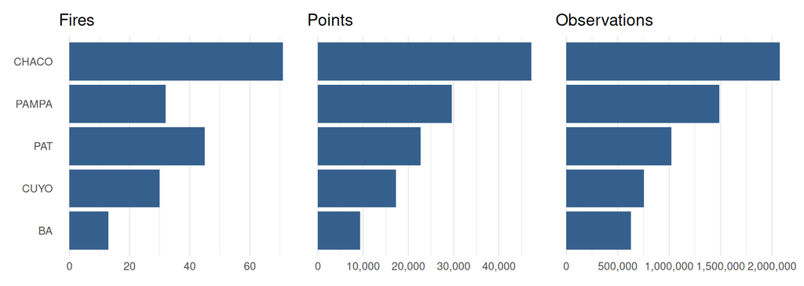

```r
by_region <- fires_burns |>
  group_by(region) |>
  summarise(
    n_fires  = n(),
    n_points = sum(n_points, na.rm = TRUE),
    n_obs    = sum(n_obs,    na.rm = TRUE),
    .groups  = "drop"
  ) |>
  arrange(desc(n_obs)) |>
  mutate(region = factor(region, levels = rev(region)))

mk_bar <- function(d, var, title, show_labels) {
  p <- ggplot(d, aes(x = .data[[var]], y = region)) +
    geom_col(fill = viridisLite::viridis(1, begin = 0.30, end = 0.30)) +
    labs(title = title, x = NULL, y = NULL) +
    scale_x_continuous(labels = comma) +
    theme_minimal(base_size = 11) +
    theme(panel.grid.major.y = element_blank())
  if (!show_labels) p <- p + theme(axis.text.y = element_blank())
  p
}

p1 <- mk_bar(by_region, "n_fires",  "Fires",        show_labels = TRUE)
p2 <- mk_bar(by_region, "n_points", "Points",       show_labels = FALSE)
p3 <- mk_bar(by_region, "n_obs",    "Observations", show_labels = FALSE)

p1 + p2 + p3
```

```r
tibble(
  ` `      = "Total",
  n_fires  = sum(by_region$n_fires),
  n_points = sum(by_region$n_points),
  n_obs    = sum(by_region$n_obs)
) |>
  kable(
    col.names   = c(" ", "Fires", "Points", "Observations"),
    format.args = list(big.mark = ",")
  )
```

|  | Fires | Points | Observations |
| --- | --- | --- | --- |
| Total | 191 | 126,106 | 5,969,279 |

## Time spent as a team

Fishing time = the effort of finding / registering each fire before sampling. PAT fires 01–30 were collected last year and averaged ~10 min per fire; the remaining fires were collected with a slower workflow averaging ~14 min.

Sampling time per fire is the `duration_min` column. For fires with no recorded duration we impute it as $\bar t_{\text{region}} \times \text{n\_points}$, where $\bar t_{\text{region}}$ is the mean recorded minutes per point in the fire’s region. The `n_estimated` column counts how many fires in the scope had their sampling time imputed this way.

```r
# Region-level mean sampling time per point, computed from `fires_burns`
# only — fire_46 / fire_47 are random-sampling outliers (5 min for 10k pts)
# and would crash the PAT rate.
region_rate <- fires_burns |>
  mutate(duration_rec = as.numeric(duration_min)) |>
  filter(!is.na(duration_rec)) |>
  group_by(region) |>
  summarise(min_per_point = sum(duration_rec) / sum(n_points), .groups = "drop")

fires_time <- fires |>
  mutate(
    is_pat_01_30   = region == "PAT" &
      fire_id %in% sprintf("fire_%02d", 1:30),
    fishing_min    = ifelse(is_pat_01_30, 10, 14),
    duration_rec   = as.numeric(duration_min),
    time_estimated = is.na(duration_rec)
  ) |>
  left_join(region_rate, by = "region") |>
  mutate(
    sampling_min = ifelse(time_estimated, n_points * min_per_point, duration_rec)
  )

summarise_time <- function(d, label) {
  tibble(
    scope      = label,
    n_fires    = nrow(d),
    fishing_h  = sum(d$fishing_min,  na.rm = TRUE) / 60,
    sampling_h = sum(d$sampling_min, na.rm = TRUE) / 60
  ) |>
    mutate(total_h = fishing_h + sampling_h)
}

bind_rows(
  summarise_time(fires_time, "Pilot + Collection 1"),
  summarise_time(filter(fires_time, !is_pat_01_30), "Collection 1")
) |>
  kable(
    digits      = 1,
    col.names   = c("Dataset", "Fires", "Fishing time (h)",
                    "Sampling time (h)", "Total time (h)"),
    format.args = list(big.mark = ","),
    caption     = "Team-wide time spent (hours). Fishing: 10 min/fire for PAT fire_01–30, 14 min/fire for the rest. Sampling: `duration_min` when recorded, otherwise imputed as `mean_min_per_point_region × n_points`."
  )
```

Team-wide time spent (hours). Fishing: 10 min/fire for PAT fire_01–30, 14 min/fire for the rest. Sampling: `duration_min` when recorded, otherwise imputed as `mean_min_per_point_region × n_points`.

| Dataset | Fires | Fishing time (h) | Sampling time (h) | Total time (h) |
| --- | --- | --- | --- | --- |
| Pilot + Collection 1 | 193 | 43 | 171.6 | 214.6 |
| Collection 1 | 163 | 38 | 135.6 | 173.6 |

## Fire-Fishers’ stats

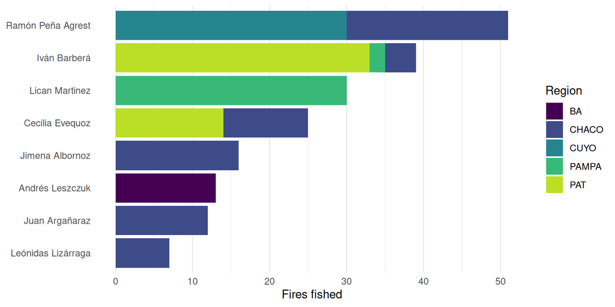

```r
fishers <- fires |>
  count(colector, region, name = "n_fires")

fisher_order <- fishers |>
  group_by(colector) |>
  summarise(total = sum(n_fires), .groups = "drop") |>
  arrange(total) |>
  pull(colector)

fishers <- fishers |>
  mutate(colector = factor(colector, levels = fisher_order))

ggplot(fishers, aes(x = n_fires, y = colector, fill = region)) +
  geom_col() +
  scale_x_continuous(labels = comma) +
  scale_fill_viridis_d(option = "D", begin = 0, end = 0.9) +
  theme_minimal(base_size = 11) +
  theme(panel.grid.major.y = element_blank()) +
  labs(x = "Fires fished", y = NULL, fill = "Region")
```

## Point-Samplers’ stats

### Fires sampled per author

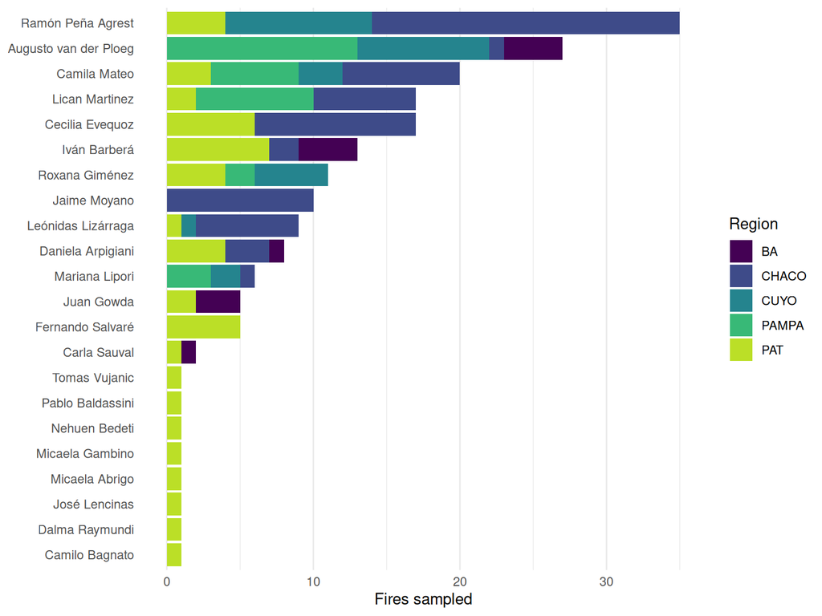

```r
samplers <- fires |>
  count(author, region, name = "n_fires")

sampler_order <- samplers |>
  group_by(author) |>
  summarise(total = sum(n_fires), .groups = "drop") |>
  arrange(total) |>
  pull(author)

samplers <- samplers |>
  mutate(author = factor(author, levels = sampler_order))

ggplot(samplers, aes(x = n_fires, y = author, fill = region)) +
  geom_col() +
  scale_x_continuous(labels = comma) +
  scale_fill_viridis_d(option = "D", begin = 0, end = 0.9) +
  theme_minimal(base_size = 11) +
  theme(panel.grid.major.y = element_blank()) +
  labs(x = "Fires sampled", y = NULL, fill = "Region")
```

### Region-diversity per author

Treating regions as “species” and number of fires per region as “abundance”, we compute Shannon’s $H = -\sum p_i \log p_i$ and Pielou’s evenness $J = H / \log S$ (with $S$ = number of regions the author worked in). Both depend only on the *proportions* $p_i$, so total abundance has no direct effect — although larger samples tend to discover more rare regions, which raises $S$. Restricted to authors with $\ge 10$ fires.

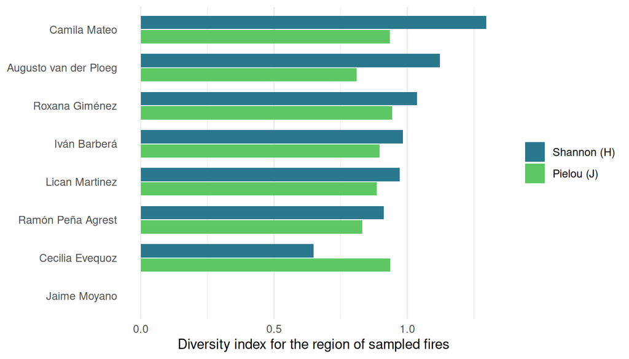

```r
ab <- fires |>
  count(author, region, name = "n")

per_author_div <- ab |>
  group_by(author) |>
  summarise(
    total   = sum(n),
    shannon = -sum((n / total) * log(n / total)),
    S       = n_distinct(region),
    pielou  = ifelse(S > 1, shannon / log(S), NA_real_),
    .groups = "drop"
  ) |>
  filter(total >= 10)

author_div_order <- per_author_div |> arrange(shannon) |> pull(author)

div_long <- bind_rows(
  per_author_div |> transmute(author, index = "Shannon (H)", value = shannon),
  per_author_div |> transmute(author, index = "Pielou (J)",  value = pielou)
) |>
  mutate(
    author = factor(author, levels = author_div_order),
    # Pielou first in factor so it dodges to the lower y, Shannon to the
    # upper y. Legend is reversed below to keep Shannon listed first.
    index  = factor(index,  levels = c("Pielou (J)", "Shannon (H)"))
  )

ggplot(div_long, aes(x = value, y = author, fill = index)) +
  geom_col(position = position_dodge(width = 0.75), width = 0.7) +
  scale_fill_manual(
    values = c(
      "Shannon (H)" = viridisLite::viridis(1, begin = 0.40, end = 0.40),
      "Pielou (J)"  = viridisLite::viridis(1, begin = 0.75, end = 0.75)
    )
  ) +
  guides(fill = guide_legend(reverse = TRUE)) +
  theme_minimal(base_size = 11) +
  theme(panel.grid.major.y = element_blank()) +
  labs(x = "Diversity index for the region of sampled fires",
       y = NULL, fill = NULL)
```

### Total points sampled per author

First with PAT fire_46 and fire_47 included (Iván’s 10 000 random points in each), then with them removed.

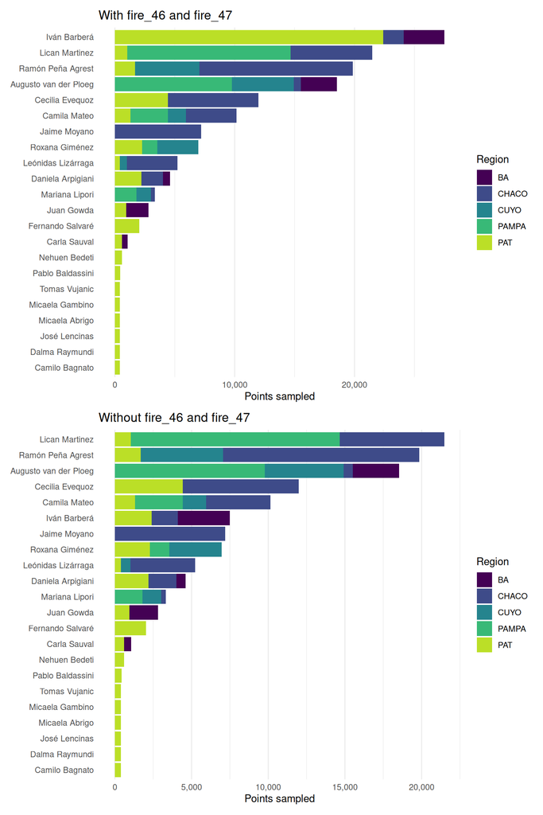

```r
plot_author_points <- function(d, title) {
  d_summary <- d |>
    group_by(author, region) |>
    summarise(n_pts = sum(n_points, na.rm = TRUE), .groups = "drop")

  ord <- d_summary |>
    group_by(author) |>
    summarise(total = sum(n_pts), .groups = "drop") |>
    arrange(total) |>
    pull(author)

  d_summary |>
    mutate(author = factor(author, levels = ord)) |>
    ggplot(aes(x = n_pts, y = author, fill = region)) +
    geom_col() +
    scale_x_continuous(labels = comma) +
    scale_fill_viridis_d(option = "D", begin = 0, end = 0.9) +
    theme_minimal(base_size = 11) +
    theme(panel.grid.major.y = element_blank()) +
    labs(title = title, x = "Points sampled", y = NULL, fill = "Region")
}

plot_author_points(fires,       "With fire_46 and fire_47") /
  plot_author_points(fires_burns, "Without fire_46 and fire_47")
```

### Sampling speed (points per minute) per author

Total points / total sampling minutes, aggregated across all the fires each author worked on. Sampling time uses recorded `duration_min` and the regional-rate imputation for missing values (same as the time-spent section). First with PAT fire_46 and fire_47, then without.

The fastest and slowest bars are highlighted (lighter shade) among authors who sampled at least **5 fires**, so that small-sample outliers don’t claim the extremes. Same rule applies to the seconds-per-point plot below.

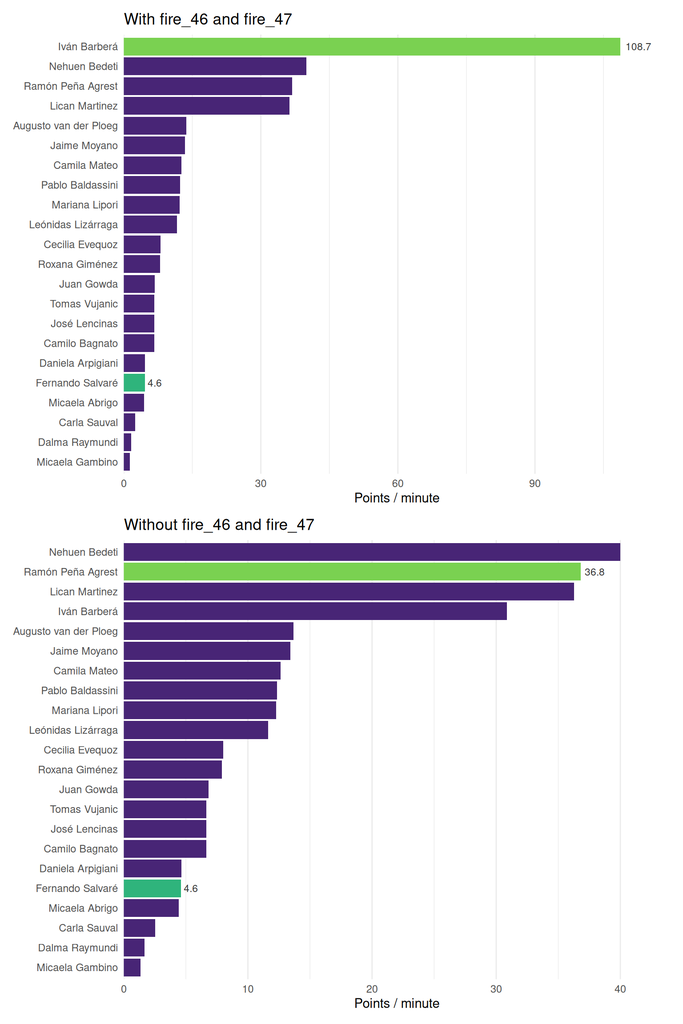

```r
# Bar colors: bulk dark; fastest and slowest highlighted lighter. Classic
# viridis (option D), values along the [0=dark, 1=light] palette axis.
# Only authors with ≥ 5 sampled fires are eligible for fastest / slowest
# (avoids singling out small-sample outliers).
bar_colors <- c(
  other   = viridisLite::viridis(1, begin = 0.10, end = 0.10),
  fastest = viridisLite::viridis(1, begin = 0.80, end = 0.80),
  slowest = viridisLite::viridis(1, begin = 0.65, end = 0.65)
)

flag_extremes <- function(authors, n_fires, metric, fastest_is) {
  # fastest_is: "max" (e.g. pts/min) or "min" (e.g. sec/pt)
  elig <- which(n_fires >= 5)
  if (length(elig) == 0) return(rep("other", length(authors)))
  if (fastest_is == "max") {
    fast_i <- elig[which.max(metric[elig])]
    slow_i <- elig[which.min(metric[elig])]
  } else {
    fast_i <- elig[which.min(metric[elig])]
    slow_i <- elig[which.max(metric[elig])]
  }
  out <- rep("other", length(authors))
  out[fast_i] <- "fastest"
  out[slow_i] <- "slowest"
  out
}

plot_author_speed <- function(d, title) {
  d_summary <- d |>
    group_by(author) |>
    summarise(
      n_fires      = n(),
      total_points = sum(n_points,     na.rm = TRUE),
      total_min    = sum(sampling_min, na.rm = TRUE),
      pts_per_min  = total_points / total_min,
      .groups      = "drop"
    ) |>
    arrange(pts_per_min) |>
    mutate(
      bar_class = flag_extremes(author, n_fires, pts_per_min, "max"),
      author    = factor(author, levels = author)
    )

  highlights <- filter(d_summary, bar_class != "other")

  ggplot(d_summary, aes(x = pts_per_min, y = author, fill = bar_class)) +
    geom_col() +
    geom_text(
      data = highlights,
      aes(label = sprintf("%.1f", pts_per_min)),
      hjust = -0.2, size = 3, colour = "grey20"
    ) +
    scale_fill_manual(values = bar_colors, guide = "none") +
    scale_x_continuous(labels = comma, expand = expansion(mult = c(0, 0.10))) +
    theme_minimal(base_size = 11) +
    theme(panel.grid.major.y = element_blank()) +
    labs(title = title, x = "Points / minute", y = NULL)
}

is_ash_drought <- function(d) {
  d$region == "PAT" & d$fire_id %in% c("fire_46", "fire_47")
}

plot_author_speed(fires_time,                              "With fire_46 and fire_47") /
  plot_author_speed(filter(fires_time, !is_ash_drought(fires_time)),
                    "Without fire_46 and fire_47")
```

### Time per point (seconds) per author

Same data, inverted to seconds-per-point — usually easier to read at a glance. Ranking is “fastest at top”.

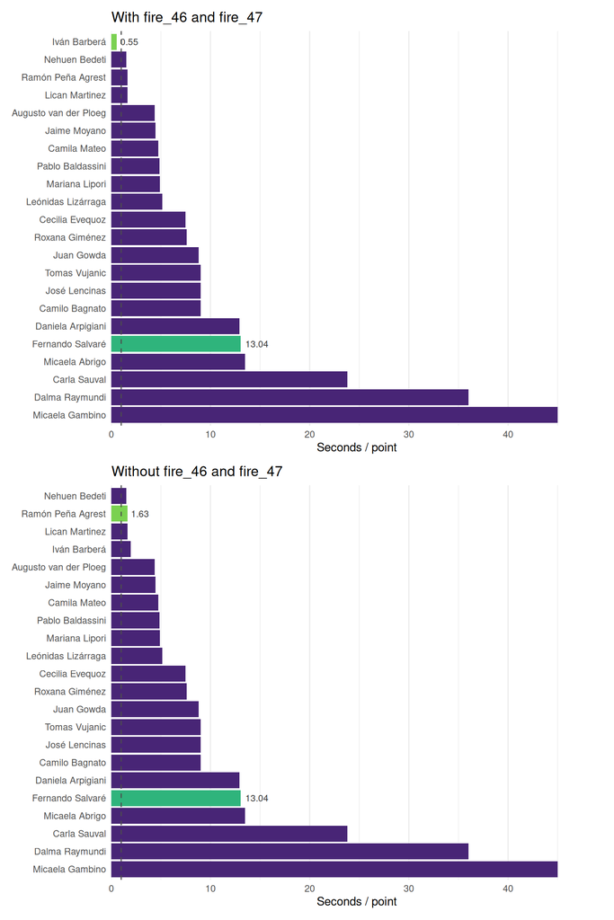

```r
plot_author_seconds <- function(d, title) {
  d_summary <- d |>
    group_by(author) |>
    summarise(
      n_fires      = n(),
      total_points = sum(n_points,     na.rm = TRUE),
      total_min    = sum(sampling_min, na.rm = TRUE),
      sec_per_pt   = total_min * 60 / total_points,
      .groups      = "drop"
    ) |>
    arrange(desc(sec_per_pt)) |>
    mutate(
      bar_class = flag_extremes(author, n_fires, sec_per_pt, "min"),
      author    = factor(author, levels = author)
    )

  highlights <- filter(d_summary, bar_class != "other")

  ggplot(d_summary, aes(x = sec_per_pt, y = author, fill = bar_class)) +
    geom_col() +
    geom_vline(xintercept = 1, linetype = "dashed", colour = "grey30") +
    geom_text(
      data = highlights,
      aes(label = sprintf("%.2f", sec_per_pt)),
      hjust = -0.2, size = 3, colour = "grey20"
    ) +
    scale_fill_manual(values = bar_colors, guide = "none") +
    scale_x_continuous(labels = comma, expand = expansion(mult = c(0, 0.10))) +
    theme_minimal(base_size = 11) +
    theme(panel.grid.major.y = element_blank()) +
    labs(title = title, x = "Seconds / point", y = NULL)
}

plot_author_seconds(fires_time,                                "With fire_46 and fire_47") /
  plot_author_seconds(filter(fires_time, !is_ash_drought(fires_time)),
                      "Without fire_46 and fire_47")
```

### Speed vs number of fires sampled

PAT fire_46 and fire_47 are excluded.

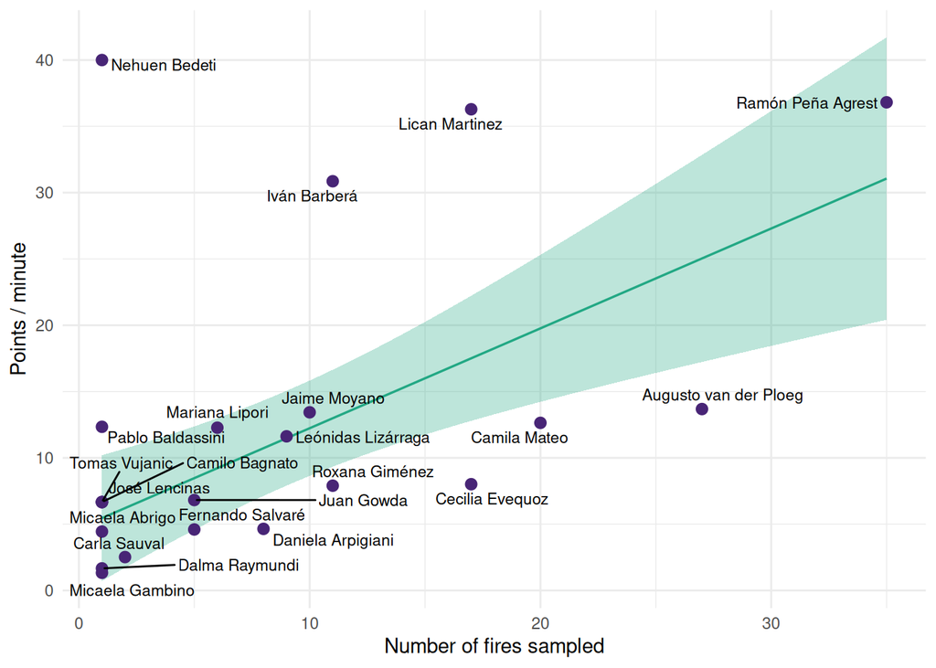

```r
scatter_data <- fires_time |>
  filter(!is_ash_drought(fires_time)) |>
  group_by(author) |>
  summarise(
    n_fires      = n(),
    total_points = sum(n_points,     na.rm = TRUE),
    total_min    = sum(sampling_min, na.rm = TRUE),
    pts_per_min  = total_points / total_min,
    .groups      = "drop"
  )

v_dark <- viridisLite::viridis(1, begin = 0.10, end = 0.10)
v_mid  <- viridisLite::viridis(1, begin = 0.60, end = 0.60)

ggplot(scatter_data, aes(x = n_fires, y = pts_per_min)) +
  geom_smooth(data = filter(scatter_data, author != "Nehuen Bedeti"),
              method = "lm", formula = y ~ x,
              colour = v_mid, fill = v_mid, alpha = 0.3, linewidth = 0.6) +
  geom_point(colour = v_dark, size = 2.5) +
  geom_text_repel(aes(label = author), size = 3, max.overlaps = Inf) +
  scale_x_continuous(breaks = pretty_breaks()) +
  theme_minimal(base_size = 11) +
  labs(x = "Number of fires sampled", y = "Points / minute")
```